# **Slide 6 - First Slide with code cell**

# **Matplotlib: Your Fundamental Canvas**

## Matplotlib is the most powerful and widely used visualization library in Python. It gives you complete and **granular control** over every element of your plot. While it might seem a bit complex at first, understanding its core concepts opens the door to creating highly customized and professional-grade visualizations. 😁

# **Understanding Figure and Axes**

## In Matplotlib, there are two key concepts you need to understand:

## **1. `Figure` (The Overall Container) 🪟**

### The Figure is essentially the entire "canvas" or "window" where your plots will be displayed.

### You can think of it as a sheet of paper on which you're going to draw.

### A Figure can contain one or more `Axes`.

## **2. `Axes` (The Plotting Area) 📊**

### The Axes is the actual plotting area(s) within the Figure. This is where your data is drawn as lines, bars, points, etc.

### Each Axes has its own X and Y axes, and you can define separate titles, labels, and scales for it.

### If you consider the Figure as a sheet of paper, the Axes is the actual "graph" or "plot" you draw on that paper.

```python
import matplotlib.pyplot as plt
import numpy as np
```

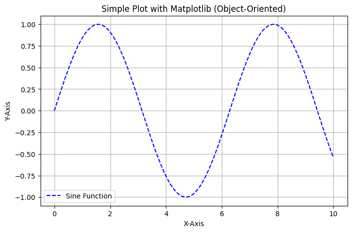

```python
# Create a Figure and a set of Axes
# plt.subplots() returns a Figure and one Axes (by default).

fig, ax = plt.subplots(figsize=(8, 5)) # figsize sets the dimensions of the Figure in inches.

# Plot data on the Axes
x = np.linspace(0, 10, 100) # 100 points between 0 and 10
y = np.sin(x) # Sine function for y

ax.plot(x, y, label='Sine Function', color='blue', linestyle='--') # Plot line on Axes
ax.set_title('Simple Plot with Matplotlib (Object-Oriented)') # Axes title
ax.set_xlabel('X-Axis') # X-axis label
ax.set_ylabel('Y-Axis') # Y-axis label
ax.legend() # Display the legend
ax.grid(True) # Show grid

# Display the Figure
plt.show()
```

# **`matplotlib.pyplot`: The Quick Interface 💻**

## `matplotlib.pyplot` is a module in Matplotlib that provides a collection of functions styled like MATLAB commands. This interface is very useful for quick starts and simple plots. Many `pyplot` functions **automatically** manage the Figure and Axes for you.

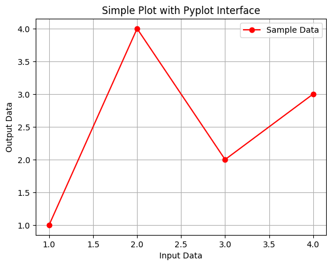

```python
# Plot using the pyplot interface

plt.plot([1, 2, 3, 4], [1, 4, 2, 3], label='Sample Data', color='red', marker='o')
plt.title('Simple Plot with Pyplot Interface')
plt.xlabel('Input Data')
plt.ylabel('Output Data')
plt.grid(True)
plt.legend()
plt.show()
```

# **Difference in Approaches:**

## **Object-Oriented Approach (`fig, ax = plt.subplots()`):** Gives you more control and is recommended for complex plots or when you want to have multiple plots within a single Figure.

## **`pyplot` Approach:** Suitable for quick and simple plots, and very practical for getting started.

### Throughout this notebook, we will explore both approaches, but our emphasis will be on the object-oriented approach to help you create more professional and customized plots.

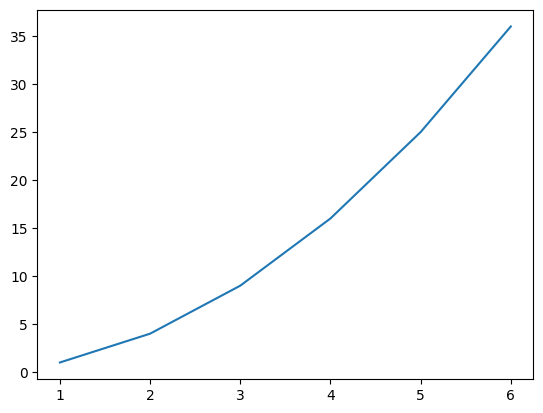

```python
import matplotlib.pyplot as plt
fig, ax = plt.subplots() # Create Axes and Figure
ax.plot([1, 2, 3, 4, 5, 6], [1, 4, 9, 16, 25, 36]) # Plot datas on Axes
plt.show()
```

[figure not shown]

```python
import matplotlib.pyplot as plt
import numpy as np
import pandas as pd

np.random.seed(42)

x_scatter = np.random.rand(50) * 10
y_scatter = np.random.rand(50) * 10 + x_scatter
colors = np.random.rand(50)
sizes = np.random.rand(50) * 800 + 100

labels = ['A', 'B', 'C', 'D']
group1_data = np.random.randint(10, 80, 4)
group2_data = np.random.randint(10, 80, 4)
x = np.arange(len(labels))
width = 0.35

years = np.arange(2010, 2016)
data_comp1 = np.random.rand(6) * 100
data_comp2 = np.random.rand(6) * 100
data_comp3 = np.random.rand(6) * 100

matrix_data = np.random.rand(10, 10) * 100

fig, axes = plt.subplots(2, 2, figsize=(12, 9))

scatter = axes[0, 0].scatter(x_scatter, y_scatter, c=colors, s=sizes, cmap='viridis', alpha=0.7, edgecolors='w', linewidth=0.5)
axes[0, 0].set_title('Scatter Plot with Color & Size')
axes[0, 0].set_xlabel('Feature 1')
axes[0, 0].set_ylabel('Feature 2')
fig.colorbar(scatter, ax=axes[0, 0], label='Value')

axes[0, 1].bar(x - width/2, group1_data, width, label='Group 1', color='skyblue')
axes[0, 1].bar(x + width/2, group2_data, width, label='Group 2', color='lightcoral')
axes[0, 1].set_title('Grouped Bar Chart')
axes[0, 1].set_ylabel('Scores')
axes[0, 1].set_xticks(x)
axes[0, 1].set_xticklabels(labels)
axes[0, 1].legend()

axes[1, 0].stackplot(years, data_comp1, data_comp2, data_comp3, labels=['Component 1', 'Component 2', 'Component 3'], alpha=0.8)
axes[1, 0].set_title('Stacked Area Plot: Trends Over Time')
axes[1, 0].set_xlabel('Year')
axes[1, 0].set_ylabel('Total Value')
axes[1, 0].legend(loc='upper left')

heatmap = axes[1, 1].imshow(matrix_data, cmap='magma', origin='lower', aspect='auto')
axes[1, 1].set_title('Heatmap: Matrix Visualization')
axes[1, 1].set_xticks(np.arange(matrix_data.shape[1]))
axes[1, 1].set_yticks(np.arange(matrix_data.shape[0]))
axes[1, 1].set_xticklabels(np.arange(1, matrix_data.shape[1] + 1))
axes[1, 1].set_yticklabels(np.arange(1, matrix_data.shape[0] + 1))
fig.colorbar(heatmap, ax=axes[1, 1], label='Intensity')

plt.tight_layout(rect=[0, 0.03, 1, 0.95])
fig.suptitle('Matplotlib\'s Multi-Panel Power: Diverse Visualizations', fontsize=18, fontweight='bold', color='darkblue')

plt.show()
```

# **Slide 7**

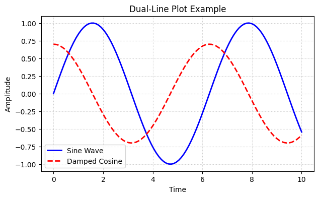

```python
import matplotlib.pyplot as plt
import numpy as np

fig, ax = plt.subplots(figsize=(7, 4))

x = np.linspace(0, 10, 100)
y1 = np.sin(x)
y2 = np.cos(x) * 0.7

ax.plot(x, y1, label='Sine Wave', color='blue', linewidth=2)
ax.plot(x, y2, label='Damped Cosine', color='red', linestyle='--', linewidth=2)

ax.set_title('Dual-Line Plot Example')
ax.set_xlabel('Time')
ax.set_ylabel('Amplitude')
ax.legend()
ax.grid(True, linestyle=':', alpha=0.7)

plt.show()
```

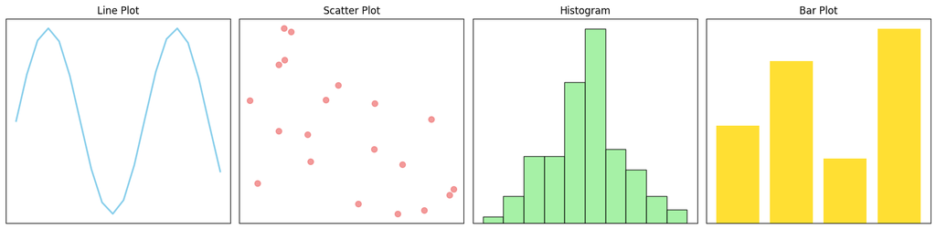

```python
import matplotlib.pyplot as plt
import numpy as np

fig, axes = plt.subplots(1, 4, figsize=(16, 4))

x_line = np.linspace(0, 10, 20)
y_line = np.sin(x_line)
axes[0].plot(x_line, y_line, color='skyblue', linewidth=2)
axes[0].set_title('Line Plot')
axes[0].set_xticks([])
axes[0].set_yticks([])

np.random.seed(42)
x_scatter = np.random.rand(20) * 10
y_scatter = np.random.rand(20) * 10
axes[1].scatter(x_scatter, y_scatter, color='lightcoral', s=50, alpha=0.8)
axes[1].set_title('Scatter Plot')
axes[1].set_xticks([])
axes[1].set_yticks([])

hist_data = np.random.normal(0, 1, 100)
axes[2].hist(hist_data, bins=10, color='lightgreen', edgecolor='black', alpha=0.8)
axes[2].set_title('Histogram')
axes[2].set_xticks([])
axes[2].set_yticks([])

categories = ['A', 'B', 'C', 'D']
values = [15, 25, 10, 30]
axes[3].bar(categories, values, color='gold', alpha=0.8)
axes[3].set_title('Bar Plot')
axes[3].set_xticks([])
axes[3].set_yticks([])

plt.tight_layout()
plt.show()
```

# **Matplotlib: Basic Plot Types 📊**

## In this section, we'll dive into creating the most fundamental and commonly used plot types in Matplotlib. Understanding these basic plots is crucial as they form the foundation for more complex visualizations. We'll use the object-oriented approach, focusing on the `Figure` and `Axes` objects for better control.

```python
import matplotlib.pyplot as plt
import numpy as np

# A good practice in Jupyter for plots to appear inline
%matplotlib inline
```

# **1. Line Plot 〰️**

## Line plots are ideal for visualizing **trends over time or continuous relationships between two variables.**

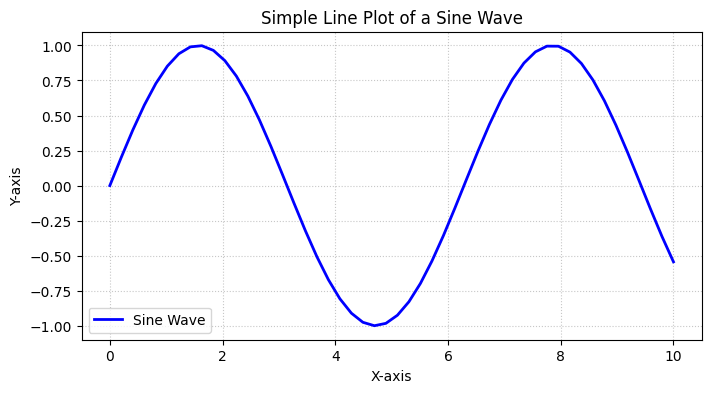

```python
# Data for Line Plot
x_line = np.linspace(0, 10, 50)
y_line = np.sin(x_line)

# Create a Figure and an Axes object
fig_line, ax_line = plt.subplots(figsize=(8, 4))

# Plot the data
ax_line.plot(x_line, y_line, color='blue', linestyle='-', linewidth=2, label='Sine Wave')

# Add titles and labels
ax_line.set_title('Simple Line Plot of a Sine Wave')
ax_line.set_xlabel('X-axis')
ax_line.set_ylabel('Y-axis')
ax_line.legend()
ax_line.grid(True, linestyle=':', alpha=0.7)

plt.show()
```

# **2. Scatter Plot 🔴**

## Scatter plots are excellent for exploring **the relationship or correlation between two numerical variables and identifying clusters or outliers.**

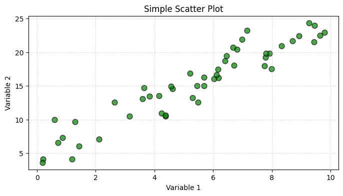

```python
# Data for Scatter Plot
np.random.seed(0) # For reproducibility
x_scatter = np.random.rand(50) * 10
y_scatter = 2 * x_scatter + np.random.randn(50) * 2 + 5

# Create a Figure and an Axes object
fig_scatter, ax_scatter = plt.subplots(figsize=(8, 4))

# Plot the data
ax_scatter.scatter(x_scatter, y_scatter, color='green', marker='o', s=60, alpha=0.7, edgecolors='black')

# Add titles and labels
ax_scatter.set_title('Simple Scatter Plot')
ax_scatter.set_xlabel('Variable 1')
ax_scatter.set_ylabel('Variable 2')
ax_scatter.grid(True, linestyle=':', alpha=0.7)

plt.show()
```

# **3. Histogram 📊**

## Histograms are used to visualize the **distribution** of a single numerical variable, showing the **frequency** of data points within different intervals (bins).

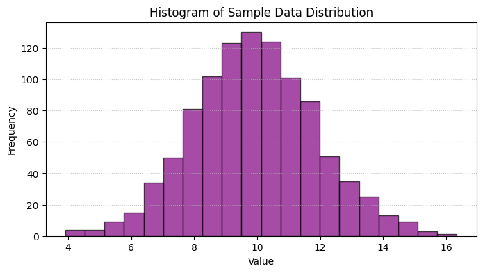

```python
# Data for Histogram
data_hist = np.random.normal(loc=10, scale=2, size=1000) # Mean 10, std dev 2, 1000 points

# Create a Figure and an Axes object
fig_hist, ax_hist = plt.subplots(figsize=(8, 4))

# Plot the histogram
ax_hist.hist(data_hist, bins=20, color='purple', edgecolor='black', alpha=0.7)

# Add titles and labels
ax_hist.set_title('Histogram of Sample Data Distribution')
ax_hist.set_xlabel('Value')
ax_hist.set_ylabel('Frequency')
ax_hist.grid(axis='y', linestyle=':', alpha=0.7)

plt.show()
```

# **4. Bar Plot 🧮**

# Bar plots are used to **compare** values across different categories or to show the **magnitude** of each category.

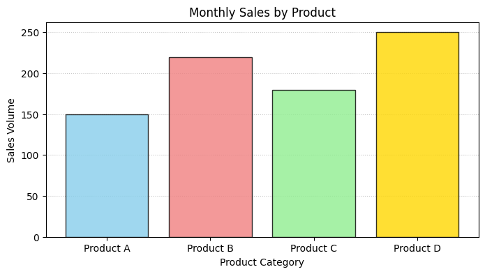

```python
# Data for Bar Plot
categories = ['Product A', 'Product B', 'Product C', 'Product D']
sales = [150, 220, 180, 250]

# Create a Figure and an Axes object
fig_bar, ax_bar = plt.subplots(figsize=(8, 4))

# Plot the bar chart
ax_bar.bar(categories, sales, color=['skyblue', 'lightcoral', 'lightgreen', 'gold'], edgecolor='black', alpha=0.8)

# Add titles and labels
ax_bar.set_title('Monthly Sales by Product')
ax_bar.set_xlabel('Product Category')
ax_bar.set_ylabel('Sales Volume')
ax_bar.grid(axis='y', linestyle=':', alpha=0.7)
ax_bar.set_axisbelow(True) # Ensure grid lines are behind bars

plt.show()
```

# **Conclusion of Basic Plots ✅**

# These four plot types are your **fundamental** building blocks in Matplotlib. By mastering them, you'll be able to **effectively** visualize a **wide** range of data. In the next section, we'll explore how to **customize** these plots to make them even more **informative** and **aesthetically pleasing**!

# **Slide 8**

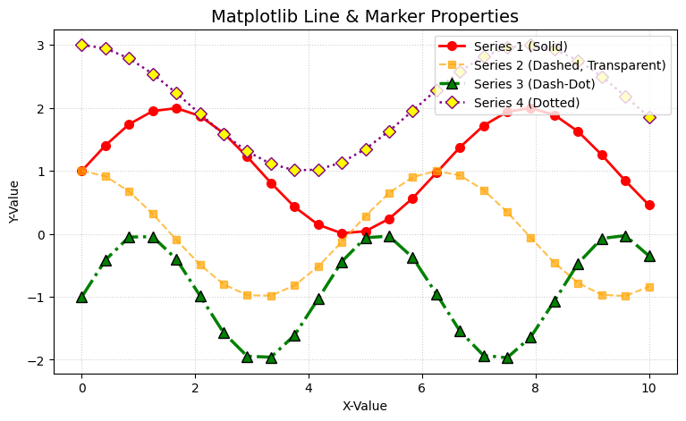

```python
import matplotlib.pyplot as plt
import numpy as np

x_data = np.linspace(0, 10, 25)
y1 = np.sin(x_data) + 1
y2 = np.cos(x_data)
y3 = np.sin(x_data * 1.5) - 1
y4 = np.cos(x_data * 0.8) + 2

fig, ax = plt.subplots(figsize=(9, 5))

ax.plot(x_data, y1, color='red', linestyle='-', linewidth=2, marker='o', markersize=7, label='Series 1 (Solid)')
ax.plot(x_data, y2, color='orange', linestyle='--', linewidth=1.5, marker='s', markersize=6, alpha=0.7, label='Series 2 (Dashed, Transparent)')
ax.plot(x_data, y3, color='green', linestyle='-.', linewidth=2.5, marker='^', markersize=8, markeredgecolor='black', label='Series 3 (Dash-Dot)')
ax.plot(x_data, y4, color='purple', linestyle=':', linewidth=1.8, marker='D', markersize=7, markerfacecolor='yellow', label='Series 4 (Dotted)')

ax.set_title('Matplotlib Line & Marker Properties', fontsize=14)
ax.set_xlabel('X-Value')
ax.set_ylabel('Y-Value')
ax.legend(loc='upper right')
ax.grid(True, linestyle=':', alpha=0.6)

plt.show()
```

# **Matplotlib: Precision & Publication ⚙️🔬**

## This section explores how to exert fine-grained control over your Matplotlib plots, moving **beyond** basic aesthetics to create **highly customized and publication-quality figures**. We'll cover **line properties, advanced subplot arrangements, and saving plots for various uses.**

```python
import matplotlib.pyplot as plt
import numpy as np
%matplotlib inline
```

# **1. Line Properties: Customizing Your Visuals 🌈**

## Matplotlib offers extensive control over how lines and markers appear. This allows you to **differentiate** data series clearly and **emphasize specific points.**

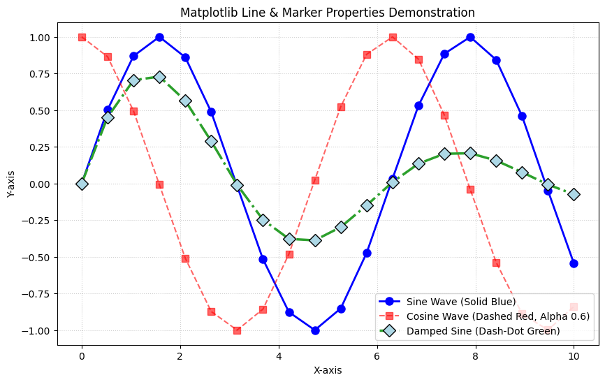

```python
# Data for line properties demonstration
x_prop = np.linspace(0, 10, 20)
y_prop1 = np.sin(x_prop)
y_prop2 = np.cos(x_prop)
y_prop3 = np.sin(x_prop) * np.exp(-x_prop/5) # Damped sine wave

fig_props, ax_props = plt.subplots(figsize=(10, 6))

# Line 1: Basic solid blue line with circular markers
ax_props.plot(x_prop, y_prop1,
              color='blue',           # Line color
              linestyle='-',          # Solid line
              linewidth=2,            # Line thickness
              marker='o',             # Circle marker
              markersize=8,           # Marker size
              label='Sine Wave (Solid Blue)')

# Line 2: Dashed red line with square markers and transparency
ax_props.plot(x_prop, y_prop2,
              color='red',
              linestyle='--',
              linewidth=1.5,
              marker='s',             # Square marker
              markersize=7,
              alpha=0.6,              # Transparency
              label='Cosine Wave (Dashed Red, Alpha 0.6)')

# Line 3: Dash-dot green line with diamond markers and larger size
ax_props.plot(x_prop, y_prop3,
              color='#2ca02c',        # Hex color code for green
              linestyle='-.',
              linewidth=2.5,
              marker='D',             # Diamond marker
              markersize=9,
              markeredgecolor='black', # Marker border color
              markerfacecolor='lightblue', # Marker fill color
              label='Damped Sine (Dash-Dot Green)')

ax_props.set_title('Matplotlib Line & Marker Properties Demonstration')
ax_props.set_xlabel('X-axis')
ax_props.set_ylabel('Y-axis')
ax_props.legend()
ax_props.grid(True, linestyle=':', alpha=0.6)

plt.show()
```

# **2.1 Subplots: Arranging Multiple Plots 🔄️**

## When you need to **display several related plots in a single figure**, `subplots` is your go-to tool. It allows for **clear comparisons and a comprehensive view of your data.**

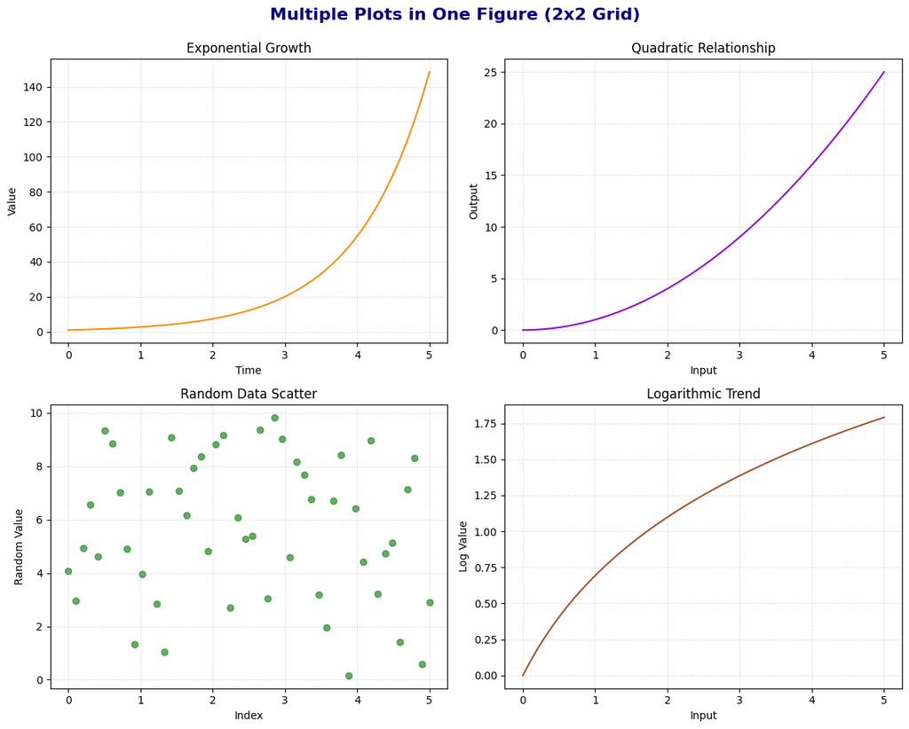

```python
# Data for subplots
x_sub = np.linspace(0, 5, 50)
y_sub1 = np.exp(x_sub)
y_sub2 = x_sub**2
y_sub3 = np.random.rand(50) * 10
y_sub4 = np.log(x_sub + 1)

# Create a 2x2 grid of subplots
fig_sub, axes_sub = plt.subplots(2, 2, figsize=(12, 10))

# Plot 1: Exponential Growth
axes_sub[0, 0].plot(x_sub, y_sub1, color='darkorange')
axes_sub[0, 0].set_title('Exponential Growth')
axes_sub[0, 0].set_xlabel('Time')
axes_sub[0, 0].set_ylabel('Value')
axes_sub[0, 0].grid(True, linestyle=':', alpha=0.6)

# Plot 2: Quadratic Relationship
axes_sub[0, 1].plot(x_sub, y_sub2, color='darkviolet')
axes_sub[0, 1].set_title('Quadratic Relationship')
axes_sub[0, 1].set_xlabel('Input')
axes_sub[0, 1].set_ylabel('Output')
axes_sub[0, 1].grid(True, linestyle=':', alpha=0.6)

# Plot 3: Random Data Distribution (Scatter)
axes_sub[1, 0].scatter(x_sub, y_sub3, color='forestgreen', alpha=0.7)
axes_sub[1, 0].set_title('Random Data Scatter')
axes_sub[1, 0].set_xlabel('Index')
axes_sub[1, 0].set_ylabel('Random Value')
axes_sub[1, 0].grid(True, linestyle=':', alpha=0.6)

# Plot 4: Logarithmic Trend
axes_sub[1, 1].plot(x_sub, y_sub4, color='sienna')
axes_sub[1, 1].set_title('Logarithmic Trend')
axes_sub[1, 1].set_xlabel('Input')
axes_sub[1, 1].set_ylabel('Log Value')
axes_sub[1, 1].grid(True, linestyle=':', alpha=0.6)

# Adjust layout to prevent overlapping
plt.tight_layout(rect=[0, 0.03, 1, 0.95])
fig_sub.suptitle('Multiple Plots in One Figure (2x2 Grid)', fontsize=16, fontweight='bold', color='navy')

plt.show()
```

# **2.2 Advanced Subplot Layouts with `fig.add_subplot()` ↕️↔️**

## For **more complex or non-uniform subplot arrangements**, `fig.add_subplot()` offers **granular control** over subplot placement. It uses a **grid specification** (rows, columns, plot_number).

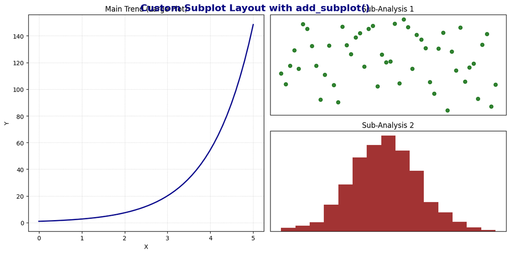

```python
# Example of a more complex subplot layout (e.g., one large plot and two smaller ones)
fig_custom = plt.figure(figsize=(12, 6))

# Large plot on the left (occupies 1st and 2nd rows, 1st column of a 2x2 conceptual grid)
ax1 = fig_custom.add_subplot(1, 2, 1) # 1 row, 2 columns, 1st plot
ax1.plot(x_sub, y_sub1, color='darkblue', linewidth=2)
ax1.set_title('Main Trend (Large Plot)')
ax1.set_xlabel('X')
ax1.set_ylabel('Y')
ax1.grid(True, linestyle=':', alpha=0.6)

# Small plots on the right (occupy 2nd column of a 2x2 conceptual grid, split vertically)
ax2 = fig_custom.add_subplot(2, 2, 2) # 2 rows, 2 columns, 2nd plot (top right)
ax2.scatter(x_sub, y_sub3, color='darkgreen', alpha=0.8)
ax2.set_title('Sub-Analysis 1')
ax2.set_xticks([]) # Remove ticks for cleaner look
ax2.set_yticks([])

ax3 = fig_custom.add_subplot(2, 2, 4) # 2 rows, 2 columns, 4th plot (bottom right)
ax3.hist(data_hist, bins=15, color='darkred', alpha=0.8)
ax3.set_title('Sub-Analysis 2')
ax3.set_xticks([])
ax3.set_yticks([])

plt.tight_layout()
fig_custom.suptitle('Custom Subplot Layout with add_subplot()', fontsize=16, fontweight='bold', color='navy')

plt.show()
```

# **3. Saving Plots for Publication 🔽**

## Once your plot is perfect, you'll often need to **save** it in a high-quality format for reports, papers, or presentations. `plt.savefig()` is your tool for this.

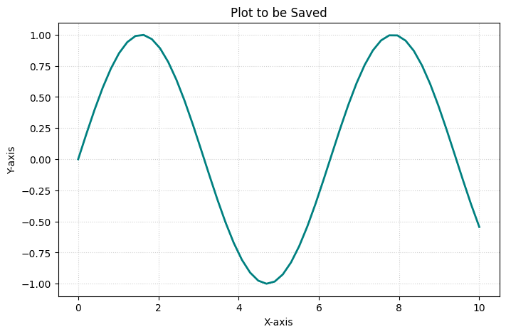

```python
# Create a simple plot to save

fig_save, ax_save = plt.subplots(figsize=(8, 5))
ax_save.plot(x_line, y_line, color='teal', linewidth=2)
ax_save.set_title('Plot to be Saved')
ax_save.set_xlabel('X-axis')
ax_save.set_ylabel('Y-axis')
ax_save.grid(True, linestyle=':', alpha=0.6)

# Save the figure in high resolution
# dpi (dots per inch) controls resolution. Use a high value for publication quality.
# bbox_inches='tight' ensures all elements (like labels) are included.

plt.savefig('my_publication_quality_plot.png', dpi=300, bbox_inches='tight')
plt.savefig('my_publication_quality_plot.pdf', bbox_inches='tight') # Also save as PDF for vector graphics

plt.show() # Display the plot in the notebook as well
```

# You can now find `my_publication_quality_plot.png` and `my_publication_quality_plot.pdf` in **your current working directory.**

# This concludes our dive into Matplotlib's fundamental and advanced controls. You now have the tools to create precise, informative, and visually stunning plots for any engineering or research task!

# **Slide 9**

[figure not shown]

```python
import matplotlib.pyplot as plt
import numpy as np
import seaborn as sns

np.random.seed(42)
n_points = 50
x_data = np.random.rand(n_points) * 10
y_data = 2 * x_data + 5 + np.random.randn(n_points) * 2

fig, axes = plt.subplots(1, 2, figsize=(14, 6))

# Matplotlib Default Scatter Plot
axes[0].scatter(x_data, y_data, color='blue', alpha=0.7)
axes[0].set_title('Matplotlib Default Scatter Plot')
axes[0].set_xlabel('X Value')
axes[0].set_ylabel('Y Value')
axes[0].grid(True, linestyle=':', alpha=0.6)

# Seaborn Enhanced Scatter Plot with Regression Line
sns.regplot(x=x_data, y=y_data, ax=axes[1], color='green', scatter_kws={'alpha':0.7, 's':60}, line_kws={'color':'red', 'linewidth':2})
axes[1].set_title('Seaborn Enhanced Scatter Plot (with Regression)')
axes[1].set_xlabel('X Value')
axes[1].set_ylabel('Y Value')
axes[1].grid(True, linestyle=':', alpha=0.6)

plt.tight_layout()
plt.show()
```

# **Seaborn: Effortless Statistical Insights ⚡🌟**

## Seaborn is a Python data visualization library **based on Matplotlib**. It provides a **high-level interface** for drawing **attractive and informative statistical graphics.** While Matplotlib gives you **granular control**, Seaborn makes common statistical plots **easy and beautiful** right out of the box.

```python
import matplotlib.pyplot as plt
import numpy as np
import pandas as pd
import seaborn as sns
%matplotlib inline
```

```python
# Set a style for better aesthetics (optional, but good for consistency)
sns.set_theme(style="whitegrid")
```

# 1. **Why Seaborn? A Visual Comparison 💥**

## Let's compare a simple plot generated with default Matplotlib settings versus the same plot generated with Seaborn. Notice the difference in **aesthetics and the simplicity of the code.**

```python
# Generate sample data for comparison
np.random.seed(42)
data_compare = np.random.normal(loc=0, scale=1, size=500) # Normally distributed data
```

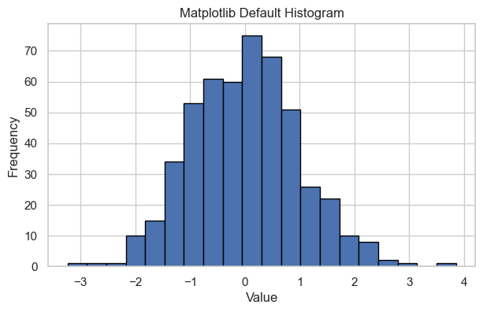

```python
# --- Matplotlib Default Histogram ---
fig_mpl, ax_mpl = plt.subplots(figsize=(7, 4))
ax_mpl.hist(data_compare, bins=20, edgecolor='black')
ax_mpl.set_title('Matplotlib Default Histogram')
ax_mpl.set_xlabel('Value')
ax_mpl.set_ylabel('Frequency')
plt.show()
```

# **Now, let's create a similar plot using Seaborn. 💥**

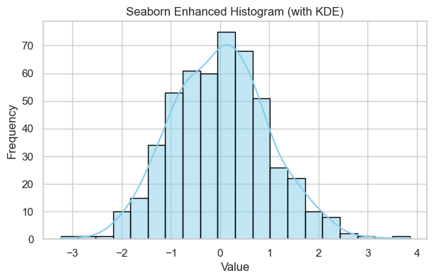

```python
fig_sns, ax_sns = plt.subplots(figsize=(7, 4))
sns.histplot(data_compare, bins=20, kde=True, color='skyblue', edgecolor='black', ax=ax_sns)
ax_sns.set_title('Seaborn Enhanced Histogram (with KDE)')
ax_sns.set_xlabel('Value')
ax_sns.set_ylabel('Frequency')
plt.show()
```

# **Key Takeaways from the Comparison:**

## **Aesthetics:** Seaborn plots often look more modern and professional by default, with better color choices and typography.

## **Functionality:** Seaborn functions often include statistical elements (like KDE in `histplot`) that would require more manual coding in Matplotlib.

## **Code Simplicity:** For common statistical plots, Seaborn typically requires fewer lines of code.

# This **ease of use** and **improved visual appeal** makes **Seaborn** an invaluable tool for **quickly** understanding your data and get insightful meaning from your data. 🔥

# **Slide 10**

[figure not shown]

```python
import matplotlib.pyplot as plt
import numpy as np
import pandas as pd
import seaborn as sns

sns.set_theme(style="whitegrid", palette="Spectral")

iris = sns.load_dataset("iris")

fig, axes = plt.subplots(2, 2, figsize=(14, 10))

sns.scatterplot(data=iris, x="sepal_length", y="sepal_width", hue="species", style="species", s=100, ax=axes[0, 0], edgecolor='w', linewidth=0.5, legend=True)
axes[0, 0].set_title('Sepal Length vs. Width by Species')
axes[0, 0].set_xlabel('Sepal Length (cm)')
axes[0, 0].set_ylabel('Sepal Width (cm)')
#axes[0, 0].legend(title='Species')

sns.kdeplot(data=iris, x="petal_length", y="petal_width", hue="species", fill=True, ax=axes[0, 1], alpha=0.6, legend=True)
axes[0, 1].set_title('Petal Length & Width Density by Species')
axes[0, 1].set_xlabel('Petal Length (cm)')
axes[0, 1].set_ylabel('Petal Width (cm)')
#axes[0, 1].legend(title='Species')

sns.barplot(data=iris, x="species", y="petal_length", hue="species", estimator=np.mean, errorbar='sd', ax=axes[1, 0], palette='viridis', legend=True)
axes[1, 0].set_title('Mean Petal Length by Species (with Std Dev)')
axes[1, 0].set_xlabel('Species')
axes[1, 0].set_ylabel('Mean Petal Length (cm)')
#axes[1, 0].legend().set_visible(False)

sns.violinplot(data=iris, x="species", y="sepal_length", hue="species", inner="quartile", ax=axes[1, 1], palette='magma', legend=True)
axes[1, 1].set_title('Sepal Length Distribution by Species')
axes[1, 1].set_xlabel('Species')
axes[1, 1].set_ylabel('Sepal Length (cm)')
#axes[1, 1].legend().set_visible(False)

plt.tight_layout(rect=[0, 0.03, 1, 0.95])
fig.suptitle('Seaborn\'s Statistical & Aesthetic Power: A Multi-View Analysis', fontsize=20, fontweight='bold', color='darkslategray')

plt.show()
```

# **2. Common Seaborn Statistical Plots 🎨**

## Seaborn provides specialized functions for **common statistical visualization tasks**. Let's explore some of the **most frequently used ones**.

```python
# Load a built-in Seaborn dataset for richer examples
# The 'tips' dataset is commonly used for demonstrating various plot types.
tips_df = sns.load_dataset('tips')
print("First 5 rows of the 'tips' dataset:")
print(tips_df.head())
print("\nDataset Info:")
tips_df.info()
```

```
First 5 rows of the 'tips' dataset:
   total_bill   tip     sex smoker  day    time  size
0       16.99  1.01  Female     No  Sun  Dinner     2
1       10.34  1.66    Male     No  Sun  Dinner     3
2       21.01  3.50    Male     No  Sun  Dinner     3
3       23.68  3.31    Male     No  Sun  Dinner     2
4       24.59  3.61  Female     No  Sun  Dinner     4

Dataset Info:
<class 'pandas.core.frame.DataFrame'>
RangeIndex: 244 entries, 0 to 243
Data columns (total 7 columns):
 #   Column      Non-Null Count  Dtype
---  ------      --------------  -----
 0   total_bill  244 non-null    float64
 1   tip         244 non-null    float64
 2   sex         244 non-null    category
 3   smoker      244 non-null    category
 4   day         244 non-null    category
 5   time        244 non-null    category
 6   size        244 non-null    int64
dtypes: category(4), float64(2), int64(1)
memory usage: 7.4 KB
```

# **2.1. Distribution Plots (`histplot`, `kdeplot`, `displot`) 🪄**

## These plots help visualize the **distribution of a single numerical variable.** `displot` is a **figure-level function** that can combine `histplot`, `kdeplot`, and `rugplot`.

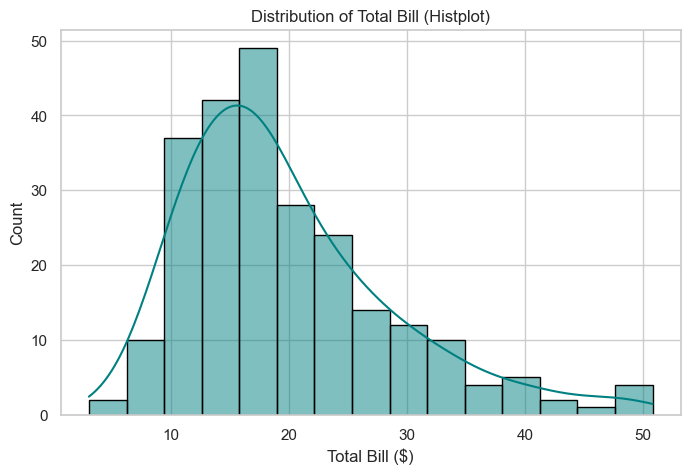

```python
# Histogram with KDE using histplot
plt.figure(figsize=(8, 5))
sns.histplot(data=tips_df, x='total_bill', kde=True, bins=15, color='teal', edgecolor='black')
plt.title('Distribution of Total Bill (Histplot)')
plt.xlabel('Total Bill ($)')
plt.ylabel('Count')
plt.show()
```

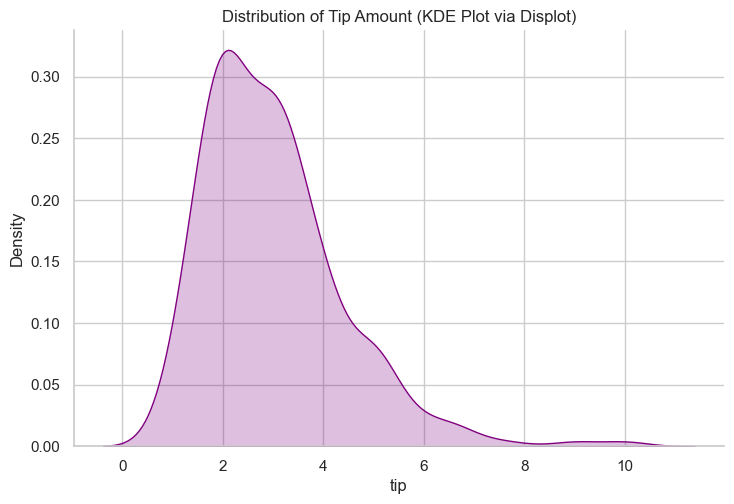

```python
# Combined distribution plot using displot
# displot is a figure-level function, so it creates its own Figure and Axes.
sns.displot(data=tips_df, x='tip', kind='kde', fill=True, color='purple', height=5, aspect=1.5)
plt.title('Distribution of Tip Amount (KDE Plot via Displot)') # Title for the figure
plt.show()
```

# **2.2. Relational Plots (`scatterplot`, `lineplot`, `relplot`) 👓**

## These plots visualize **the relationship between two or more variables.** `relplot` is a **figure-level function** that can create `scatterplot` or `lineplot` **and allows for easy faceting.**

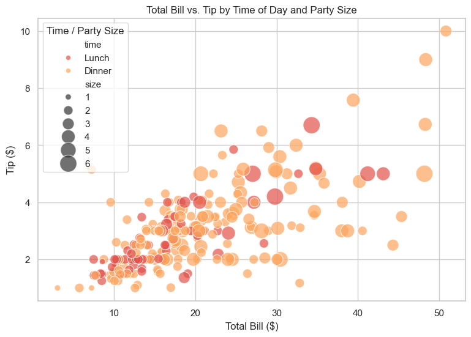

```python
# Scatter plot with hue and size mapping
plt.figure(figsize=(9, 6))
sns.scatterplot(data=tips_df, x='total_bill', y='tip', hue='time', size='size', sizes=(50, 400), alpha=0.7, edgecolor='w')
plt.title('Total Bill vs. Tip by Time of Day and Party Size')
plt.xlabel('Total Bill ($)')
plt.ylabel('Tip ($)')
plt.legend(title='Time / Party Size')
plt.show()
```

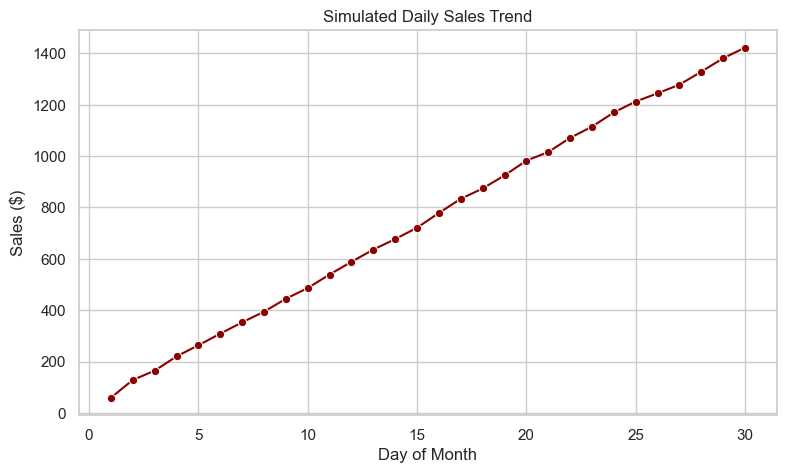

```python
# Line plot (for ordered data, though tips_df is not time-series, this demonstrates basic usage)
# Let's create some dummy time-series like data for demonstration 🤪
time_data = pd.DataFrame({
    'Day': np.arange(1, 31),
    'Sales': np.cumsum(np.random.randn(30) * 10 + 50)
})
plt.figure(figsize=(9, 5))
sns.lineplot(data=time_data, x='Day', y='Sales', color='darkred', marker='o')
plt.title('Simulated Daily Sales Trend')
plt.xlabel('Day of Month')
plt.ylabel('Sales ($)')
plt.show()
```

# **2.3. Categorical Plots (`boxplot`, `violinplot`, `catplot`) 📱**

## These plots visualize **the relationship between a numerical variable and one or more categorical variables.** `catplot` is a **figure-level function** for categorical plots.

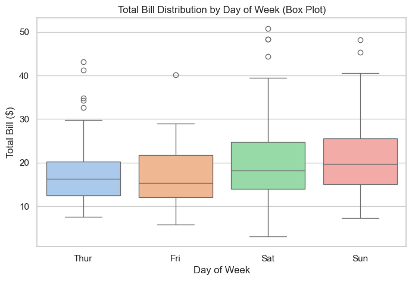

```python
# Box Plot: Distribution of total bill by day
plt.figure(figsize=(8, 5))
sns.boxplot(data=tips_df, x='day', y='total_bill', hue='day', palette='pastel', legend=False)
plt.title('Total Bill Distribution by Day of Week (Box Plot)')
plt.xlabel('Day of Week')
plt.ylabel('Total Bill ($)')
plt.show()
```

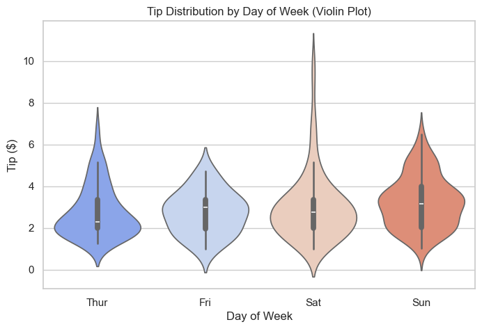

```python
# Violin Plot: Distribution of tip by day
plt.figure(figsize=(8, 5))
sns.violinplot(data=tips_df, x='day', y='tip', hue='day', palette='coolwarm', legend=False)
plt.title('Tip Distribution by Day of Week (Violin Plot)')
plt.xlabel('Day of Week')
plt.ylabel('Tip ($)')
plt.show()
```

# **2.4. Matrix Plots (`heatmap`) 🔠**

## Heatmaps are excellent for visualizing **matrices, such as correlation matrices**, where the **intensity** of color represents the **value**.

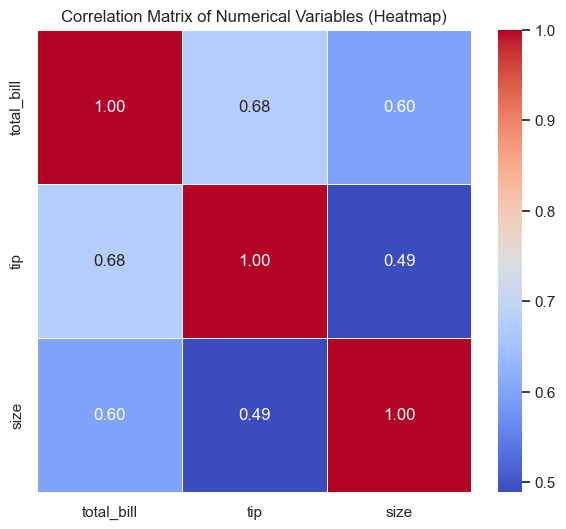

```python
# Calculate correlation matrix
correlation_matrix = tips_df[['total_bill', 'tip', 'size']].corr()

# Create a heatmap
plt.figure(figsize=(7, 6))
sns.heatmap(correlation_matrix, annot=True, cmap='coolwarm', fmt=".2f", linewidths=.5)
plt.title('Correlation Matrix of Numerical Variables (Heatmap)')
plt.show()
```

# **Conclusion: Seaborn's Power for Statistical Analysis 🪄💥🔥**

## Seaborn streamlines the process of creating visually **appealing and statistically informative plots**. By **abstracting** much of the Matplotlib **boilerplate**, it allows you to **focus more on the data and less on the plotting mechanics**. This makes it an indispensable tool for **Exploratory Data Analysis** and communicating **complex** statistical relationships **effectively**.

# **Slide 11**

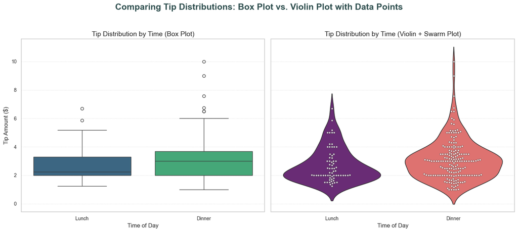

```python
import matplotlib.pyplot as plt
import numpy as np
import pandas as pd
import seaborn as sns

sns.set_theme(style="whitegrid", palette="deep")

tips = sns.load_dataset("tips")

fig, axes = plt.subplots(1, 2, figsize=(15, 7), sharey=True)

sns.boxplot(data=tips, x="time", y="tip", ax=axes[0], hue="time", legend=False, palette="viridis")
axes[0].set_title('Tip Distribution by Time (Box Plot)', fontsize=14)
axes[0].set_xlabel('Time of Day', fontsize=12)
axes[0].set_ylabel('Tip Amount ($)', fontsize=12)
axes[0].tick_params(labelsize=10)
axes[0].grid(axis='y', linestyle=':', alpha=0.7)

sns.violinplot(data=tips, x="time", y="tip", ax=axes[1], hue="time", legend=False, palette="magma", inner=None)
sns.swarmplot(data=tips, x="time", y="tip", ax=axes[1], color="white", edgecolor="black", linewidth=0.5, size=4, alpha=0.7)
axes[1].set_title('Tip Distribution by Time (Violin + Swarm Plot)', fontsize=14)
axes[1].set_xlabel('Time of Day', fontsize=12)
axes[1].set_ylabel('')
axes[1].tick_params(labelsize=10)
axes[1].grid(axis='y', linestyle=':', alpha=0.7)

fig.suptitle('Comparing Tip Distributions: Box Plot vs. Violin Plot with Data Points', fontsize=18, fontweight='bold', color='darkslategray')

plt.tight_layout(rect=[0, 0.03, 1, 0.95])
plt.show()
```

# **3. Comparing Distributions Across Categories ✳️**

## Understanding how a numerical variable's distribution **differs** across various categories is a fundamental task in data analysis. Seaborn provides powerful tools like `boxplot` and `violinplot` to **quickly reveal these insights.**

```python
# Load the Iris🌸 dataset for a classic comparison example
# This dataset contains measurements of iris flowers, categorized by species.
iris_df = sns.load_dataset('iris')
print("\nFirst 5 rows of the 'iris' dataset:")
print(iris_df.head())
print("\nDataset Info:")
iris_df.info()
```

```
First 5 rows of the 'iris' dataset:
   sepal_length  sepal_width  petal_length  petal_width species
0           5.1          3.5           1.4          0.2  setosa
1           4.9          3.0           1.4          0.2  setosa
2           4.7          3.2           1.3          0.2  setosa
3           4.6          3.1           1.5          0.2  setosa
4           5.0          3.6           1.4          0.2  setosa

Dataset Info:
<class 'pandas.core.frame.DataFrame'>
RangeIndex: 150 entries, 0 to 149
Data columns (total 5 columns):
 #   Column        Non-Null Count  Dtype
---  ------        --------------  -----
 0   sepal_length  150 non-null    float64
 1   sepal_width   150 non-null    float64
 2   petal_length  150 non-null    float64
 3   petal_width   150 non-null    float64
 4   species       150 non-null    object
dtypes: float64(4), object(1)
memory usage: 6.0+ KB
```

# **3.1. `sns.boxplot()`: Quick Summaries and Outlier Detection 🌸**

## The box plot summarizes the data's distribution using **quartiles (25th, 50th/median, 75th percentiles) and highlights potential outliers.** It's excellent for a **concise comparison of central tendency and spread across groups.**

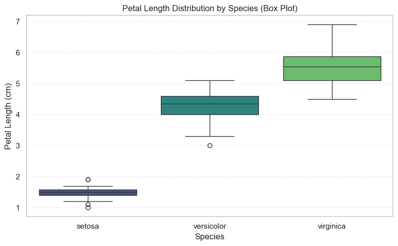

```python
fig, ax = plt.subplots(figsize=(8, 5))

# Box plot: Petal Length distribution by Species from 'iris' dataset
sns.boxplot(data=iris_df, x='species', y='petal_length', palette='viridis', ax=ax, hue='species', legend=False)
ax.set_title('Petal Length Distribution by Species (Box Plot)')
ax.set_xlabel('Species')
ax.set_ylabel('Petal Length (cm)')
ax.grid(axis='y', linestyle=':', alpha=0.6)

plt.tight_layout()
plt.show()
```

# **3.2. `sns.violinplot()`: Full Distribution Shape and Density 🪷**

## The violin plot extends the box plot by showing the **full probability density of the data at different values**. It's particularly useful for revealing **multi-modal distributions or subtle shape differences between categories.**

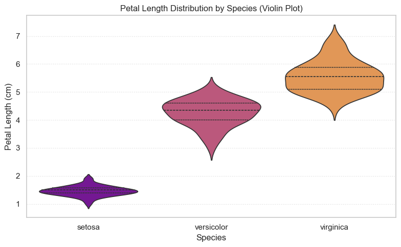

```python
sns.set_theme(style="whitegrid", palette="viridis")

iris_df = sns.load_dataset('iris')

# Create a Figure and a single Axes specifically for this violin plot
fig, ax = plt.subplots(figsize=(8, 5))

# Violin Plot: Petal Length distribution by Species from 'iris' dataset
# Fix applied: Added hue='species' and legend=False to address the FutureWarning.
sns.violinplot(data=iris_df, x='species', y='petal_length', palette='plasma', inner='quartile', ax=ax, hue='species', legend=False)
ax.set_title('Petal Length Distribution by Species (Violin Plot)')
ax.set_xlabel('Species')
ax.set_ylabel('Petal Length (cm)')
ax.grid(axis='y', linestyle=':', alpha=0.6)

plt.tight_layout()
plt.show()
```

# **When to Use Which? 🤔**

## **`boxplot`**: Choose `boxplot` for a **quick, concise summary of central tendency, spread, and outliers**. It's great when you have **many categories or want to focus on key statistical measures.**

## **`violinplot`**: Opt for `violinplot` when you need to understand the *full shape of the distribution* within each category, including whether it's **unimodal, bimodal, or skewed**. It provides **more detail about the data's density.**

## Both plots are invaluable for **identifying differences and similarities in data spread between groups**, helping you make informed decisions in your engineering and data analysis tasks.

# **Slide 12**

[figure not shown]

```python
import matplotlib.pyplot as plt
import numpy as np
import pandas as pd
import seaborn as sns

sns.set_theme(style="whitegrid", palette="deep")

flights = sns.load_dataset("flights")

fig, axes = plt.subplots(1, 2, figsize=(18, 8))

sns.lineplot(data=flights, x="year", y="passengers", hue="month",
             marker="o", linewidth=1.5, alpha=0.8,
             ax=axes[0])
axes[0].set_title('Monthly Passenger Trends Over Years', fontsize=16)
axes[0].set_xlabel('Year', fontsize=12)
axes[0].set_ylabel('Number of Passengers', fontsize=12)
axes[0].legend(title='Month', bbox_to_anchor=(1.02, 1), loc='upper left', borderaxespad=0)
axes[0].grid(True, linestyle=':', alpha=0.6)

flights_pivot = flights.pivot_table(index='month', columns='year', values='passengers', observed=False)
sns.heatmap(flights_pivot, annot=True, fmt=".0f", cmap='viridis', linewidths=.5, linecolor='white',
            cbar_kws={'label': 'Number of Passengers'},
            ax=axes[1])
axes[1].set_title('Passenger Traffic Heatmap (Month vs. Year)', fontsize=16)
axes[1].set_xlabel('Year', fontsize=12)
axes[1].set_ylabel('Month', fontsize=12)
axes[1].tick_params(axis='x', rotation=45)
axes[1].tick_params(axis='y', rotation=0)

plt.tight_layout(rect=[0, 0.03, 1, 0.95])
fig.suptitle('Seaborn: Unveiling Time-Series & Matrix Relationships', fontsize=22, fontweight='bold', color='darkslategray')

plt.show()
```

# **4. Uncovering Relationships ⁉️**

## **Understanding the relationships between variables** is paramount in data analysis, especially in machine learning. Seaborn provides powerful and intuitive tools to visualize these **connections**, **helping us identify correlations, clusters, and multi-dimensional patterns that might be hidden in raw data.**

```python
# Load the Iris dataset again for relationship plots

iris_df_rel = sns.load_dataset('iris')
print("\nFirst 5 rows of the 'iris' dataset for relationship plots:")
print(iris_df_rel.head())
```

```
First 5 rows of the 'iris' dataset for relationship plots:
   sepal_length  sepal_width  petal_length  petal_width species
0           5.1          3.5           1.4          0.2  setosa
1           4.9          3.0           1.4          0.2  setosa
2           4.7          3.2           1.3          0.2  setosa
3           4.6          3.1           1.5          0.2  setosa
4           5.0          3.6           1.4          0.2  setosa
```

# **4.1. `sns.scatterplot()` with `hue` and `size`: Multi-Dimensional Insights 🔅**

## The scatter plot is a fundamental tool for showing the **relationship between two numerical variables.** Seaborn enhances this by allowing you to **map additional variables to visual properties like color (`hue`) and point size (`size`)**, effectively visualizing **three or even four dimensions of data 😲**.

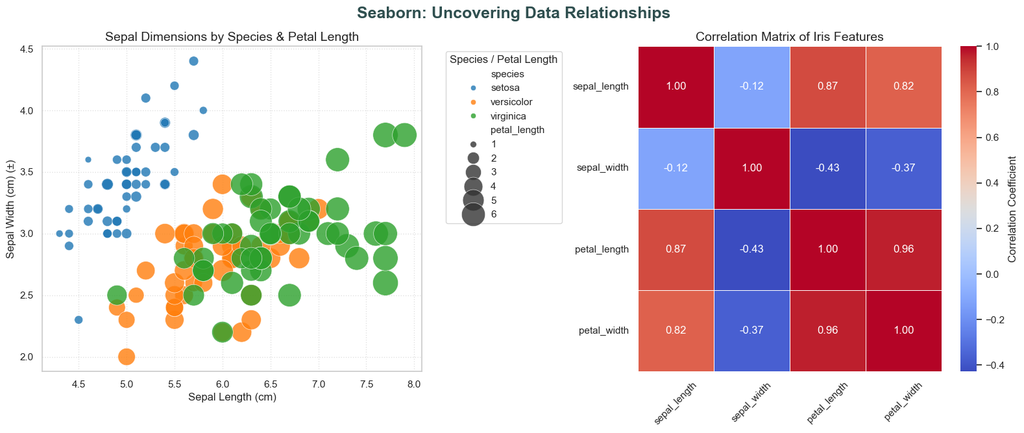

```python
import matplotlib.pyplot as plt
import numpy as np
import pandas as pd
import seaborn as sns

# Set a vibrant and contrasting Seaborn theme for a "WOW" effect
sns.set_theme(style="whitegrid", palette="deep")

# Load the Iris dataset (assuming iris_df_rel is meant to be iris)
iris_df_rel = sns.load_dataset("iris")

# Create a Figure with 1 row and 2 columns of Axes (subplots)
fig_rel, axes_rel = plt.subplots(1, 2, figsize=(16, 7))

# Scatter Plot with hue (species) and size (petal_width)
sns.scatterplot(data=iris_df_rel, x='sepal_length', y='sepal_width',
                hue='species', # Map 'species' to color
                size='petal_length', # Map 'petal_length' to marker size
                sizes=(50, 800), # Range of marker sizes
                alpha=0.8, # Transparency for overlapping points
                edgecolor='w', # White edge for markers
                linewidth=0.5, # Line width for marker edge
                ax=axes_rel[0], # Plot on the first Axes (left)
                palette='tab10') # Use a distinct categorical palette

axes_rel[0].set_title('Sepal Dimensions by Species & Petal Length', fontsize=14)
axes_rel[0].set_xlabel('Sepal Length (cm)', fontsize=12)
axes_rel[0].set_ylabel('Sepal Width (cm) (±)', fontsize=12) # Added (±) as seen in user's image
axes_rel[0].legend(title='Species / Petal Length', bbox_to_anchor=(1.05, 1), loc='upper left') # Place legend outside
axes_rel[0].grid(True, linestyle=':', alpha=0.6)

# Calculate the correlation matrix for numerical features in the Iris dataset
correlation_matrix_iris = iris_df_rel.drop(columns=['species']).corr()

# Create a heatmap of the correlation matrix
sns.heatmap(correlation_matrix_iris,
            annot=True, # Show the correlation values on the heatmap
            cmap='coolwarm', # Colormap (e.g., 'coolwarm', 'viridis', 'magma')
            fmt=".2f", # Format annotation values to 2 decimal places
            linewidths=.5, # Add lines between cells
            cbar_kws={'label': 'Correlation Coefficient'}, # Label for the color bar
            ax=axes_rel[1]) # Plot on the second Axes

axes_rel[1].set_title('Correlation Matrix of Iris Features', fontsize=14)
axes_rel[1].tick_params(axis='x', rotation=45) # Rotate x-axis labels for better readability
axes_rel[1].tick_params(axis='y', rotation=0) # Ensure y-axis labels are horizontal

plt.tight_layout(rect=[0, 0.03, 1, 0.95]) # Adjust layout to make space for suptitle
fig_rel.suptitle('Seaborn: Uncovering Data Relationships', fontsize=18, fontweight='bold', color='darkslategray')

plt.show()
```

# **4.2. `sns.heatmap()`: Visualizing Correlation Matrices 📱👆**

## Heatmaps are incredibly useful for visualizing matrices, especially **correlation matrices**, which are crucial in machine learning for understanding **feature interactions and multicollinearity**. The **intensity of color** directly represents the **value**.

# **Conclusion: Unlocking Deeper Insights ✨**

## `scatterplot` with `hue` and `size` allows us to visualize complex, multi-dimensional relationships, while `heatmap` provides a clear, immediate understanding of correlations within your dataset. These powerful tools are essential for:

## **Feature Engineering:** Identifying which features are most **relevant or redundant.**

## **Model Interpretation:** Understanding **how different input variables might influence your model's predictions.**

## **Data Storytelling:** Communicating complex interactions in an intuitive and impactful way.

### **Mastering these plots will significantly enhance your ability to perform comprehensive data analysis and build more robust machine learning models. 😊✌️**

# **Slide 13**

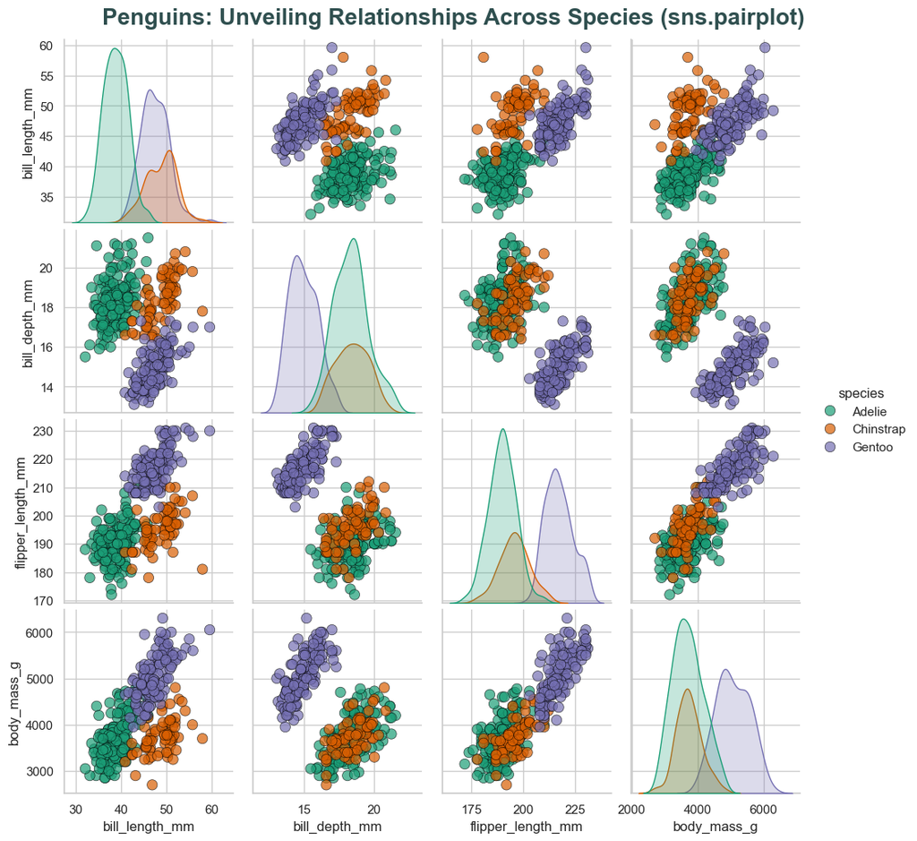

```python
import matplotlib.pyplot as plt
import numpy as np
import pandas as pd
import seaborn as sns

# 'viridis', 'plasma', 'magma', 'cividis' are great sequential palettes.
# For categorical data, 'tab10', 'Paired', 'Set1', 'Dark2' are good.
sns.set_theme(style="whitegrid", palette="Dark2") # Using 'Dark2' for distinct species colors

# Load the built-in 'penguins' dataset
# This dataset contains measurements for different penguin species
penguins = sns.load_dataset("penguins")

# Create a pairplot for the penguins dataset
# 'hue' maps the 'species' column to different colors, clearly separating groups.
# 'diag_kind="kde"' shows Kernel Density Estimates on the diagonal, revealing distribution shapes.
# 'height' controls the size of each subplot in the grid.
g = sns.pairplot(data=penguins, hue="species", diag_kind="kde", height=2.5,
                 plot_kws={'alpha': 0.7, 's': 80, 'edgecolor': 'black', 'linewidth': 0.5}) # Customizing scatter points

# Add a super title for the entire Figure
g.fig.suptitle('Penguins: Unveiling Relationships Across Species (sns.pairplot)', y=1.02, # Adjust y to prevent overlap
               fontsize=20, fontweight='bold', color='darkslategray')

plt.show()
```